# Supervised Learning Packages

Jindra

11/29/2017

## Decision trees

Decision trees work by building a tree from the input data, splitting on a parameter in each inner node according to a variable value. This can be splitting on whether a numerical value is above or below a certain threshold or which level a factor has.

```r
library(rpart)
library(Metrics)
library(mlbench)
library(magrittr)
suppressMessages(library(dplyr))
data(cars)
data(BreastCancer)
model <- cars %>% rpart(dist ~ speed, data = .)
rmse(predict(model, cars), cars$dist)
```

```
## [1] 16.5693
```

Building a classifying model works very similar. We do not need to translate the cell thickness into a numerical value, though. The predictions when we used the glm() function were probabilities for the tumor being malignant. The predictions made using the decision tree gives you the probabilities both for being benign and being malignant:

```r
model <- BreastCancer %>% rpart(Class ~ Cl.thickness, data = .)
predict(model, BreastCancer) %>% head
```

```
##       benign malignant
## 1 0.82815356 0.1718464
## 2 0.82815356 0.1718464
## 3 0.82815356 0.1718464
## 4 0.82815356 0.1718464
## 5 0.82815356 0.1718464
## 6 0.03289474 0.9671053
```

To get a confusion matrix, we need to translate these probabilities into the corresponding classes.

```r
#The output of predict() is not a data frame but a matrix so we first convert it into a data frame
predicted_class <- predict(model, BreastCancer) %>%
  as.data.frame %$%
  ifelse(benign > 0.5, "benign", "malignant")

table(BreastCancer$Class, predicted_class)
```

```
##            predicted_class
##             benign malignant
##   benign       453         5
##   malignant     94       147
```

### Another decision trees package

```r
#install.packages("party")
suppressMessages(library(party))
#regression
model <- cars %>% ctree(dist ~ speed, data = .)
rmse(predict(model,cars), cars$dist)
```

```
## [1] 16.5693
```

```r
#classification
model <- BreastCancer %>% ctree(Class ~ Cl.thickness, data = .)
predict(model, BreastCancer) %>% head
```

```
## [1] benign    benign    benign    benign    benign    malignant
## Levels: benign malignant
```

```r
table(BreastCancer$Class, predict(model, BreastCancer))
```

```
##
##             benign malignant
##   benign       453         5
##   malignant     94       147
```

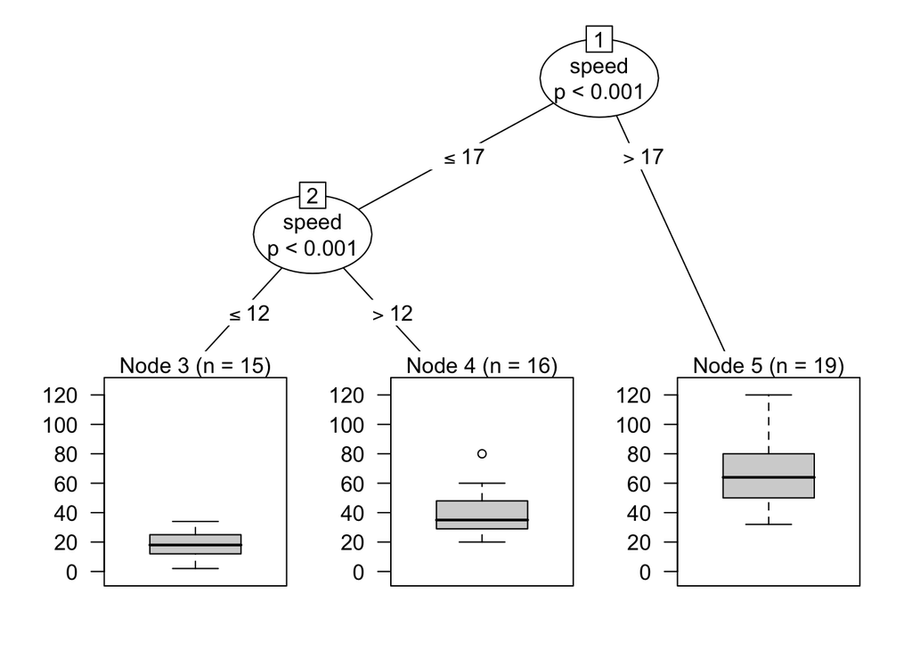

```r
#this package also allows plotting
cars %>% ctree(dist ~ speed, data = .) %>% plot
```

## Random forests

Random forests generalize decision trees by building several of them and combining them.

```r
#install.packages("randomForest")
suppressMessages(library(randomForest))
model <- cars %>% randomForest(dist ~ speed, data = .)
rmse(predict(model, cars), cars$dist)
```

```
## [1] 11.82804
```

```r
#For classification, the predictions are the actual classes as a factor, so no translation is needed to get a confusion matrix
model <- BreastCancer %>% randomForest(Class ~ Cl.thickness, data = .)
predict(model, BreastCancer) %>% head
```

```
##         1         2         3         4         5         6
##    benign    benign    benign malignant    benign malignant
## Levels: benign malignant
```

```r
table(BreastCancer$Class,
      predict(model, BreastCancer),
      dnn = c("Reality","Predicted"))
```

```
##            Predicted
## Reality     benign malignant
##   benign       437        21
##   malignant     76       165
```

## Neural Networks

```r
library(nnet) #size specifies how many nodes are in inner layer
#regression
model <- cars %>% nnet(dist ~ speed, data = ., size = 5)
rmse(predict(model, cars), cars$dist)
```

```
## [1] 49.12331
```

```r
#classofication
model <- BreastCancer %>% nnet(Class ~ Cl.thickness, data = ., size = 5)
#The output of the predict() function is probabilities for the tumor being malignant:
predict(model, BreastCancer) %>% head
```

```
##        [,1]
## 1 0.3461773
## 2 0.3461773
## 3 0.1111005
## 4 0.5293132
## 5 0.1499806
## 6 0.9131250
```

```r
#translate it into classes, we can use a lambda expression:
predicted_class <- predict(model, BreastCancer) %>%
  {ifelse(. < 0.5, "benign", "malignant")}
table(BreastCancer$Class, predicted_class)
```

```
##            predicted_class
##             benign malignant
##   benign       437        21
##   malignant     76       165
```

## Support vector machines

```r
#install.packages("kernlab")
suppressMessages(library(kernlab))
#regression
model <- cars %>% ksvm(dist ~ speed, data = .)
rmse(predict(model, cars), cars$dist)
```

```
## [1] 14.20222
```

```r
#classification
model <- BreastCancer %>% ksvm(Class ~ Cl.thickness, data = .)
predict(model, BreastCancer) %>% head
```

```
## [1] benign    benign    benign    malignant benign    malignant
## Levels: benign malignant
```

```r
table(BreastCancer$Class, predict(model, BreastCancer))
```

```
##
##             benign malignant
##   benign       437        21
##   malignant     76       165
```

## Naive Bayes

Naive Bayes essentially assumes that each explanatory variable is independent of the others and uses the distribution of these for each category of data to construct the distribution of the response variable given the explanatory variables. The implemented package supports only classification

```r
#install.packages("e1071")
library(e1071)
model <- BreastCancer %>% naiveBayes(Class ~ Cl.thickness, data = .)
predict(model, BreastCancer) %>% head
```

```
## [1] benign    benign    benign    malignant benign    malignant
## Levels: benign malignant
```

```r
table(BreastCancer$Class, predict(model, BreastCancer))
```

```
##
##             benign malignant
##   benign       437        21
##   malignant     76       165
```